# Customer Segmentation Analysis

**Track:** Data Analytics — Level 1, Task 2 **Objective:** Apply clustering to segment an e-commerce company's customers into distinct groups based on purchasing behaviour, enabling targeted marketing.

Dataset: `ecommerce_customer_data.csv` — per-customer Recency (days since last purchase), Frequency (number of purchases), and Monetary (total spend) values.

```python
import pandas as pd
import numpy as np
import matplotlib.pyplot as plt
import seaborn as sns
from sklearn.preprocessing import StandardScaler
from sklearn.cluster import KMeans

sns.set_theme(style="whitegrid")
plt.rcParams["figure.figsize"] = (9,5)

df = pd.read_csv("ecommerce_customer_data.csv")
df.head()
```

|  | CustomerID | Recency | Frequency | Monetary |
| --- | --- | --- | --- | --- |
| 0 | CUST1000 | 144 | 5 | 4163.99 |
| 1 | CUST1001 | 7 | 41 | 1764.54 |
| 2 | CUST1002 | 72 | 2 | 11907.55 |
| 3 | CUST1003 | 91 | 7 | 6946.34 |
| 4 | CUST1004 | 179 | 2 | 7743.23 |

## 1. Inspect & Clean

```python
print(df.shape)
print(df.isnull().sum())
print("Duplicates:", df.duplicated().sum())

df = df.drop_duplicates().reset_index(drop=True)
df["Monetary"] = df["Monetary"].fillna(df["Monetary"].median())
print("After cleaning:", df.shape, "| remaining nulls:", df.isnull().sum().sum())
```

```
(602, 4)
CustomerID    0
Recency       0
Frequency     0
Monetary      8
dtype: int64
Duplicates: 2
After cleaning: (600, 4) | remaining nulls: 0
```

## 2. Descriptive Statistics

```python
df[["Recency","Frequency","Monetary"]].describe()
```

|  | Recency | Frequency | Monetary |
| --- | --- | --- | --- |
| count | 600.000000 | 600.000000 | 600.000000 |
| mean | 88.986667 | 18.446667 | 6517.301117 |
| std | 102.882901 | 15.355025 | 6713.426425 |
| min | 1.000000 | 1.000000 | 102.570000 |
| 25% | 7.000000 | 4.000000 | 1290.777500 |
| 50% | 17.000000 | 18.000000 | 2855.780000 |
| 75% | 159.000000 | 31.000000 | 10360.572500 |
| max | 358.000000 | 49.000000 | 24645.010000 |

**Observation:** `Monetary` is right-skewed with a wide range, while `Recency` shows two rough groupings — customers who purchased very recently and customers who haven't purchased in months.

## 3. Feature Selection — RFM Analysis

We use **Recency, Frequency, Monetary (RFM)** — the three classic behavioural features for customer segmentation.

```python
features = df[["Recency", "Frequency", "Monetary"]]
features.head()
```

|  | Recency | Frequency | Monetary |
| --- | --- | --- | --- |
| 0 | 144 | 5 | 4163.99 |
| 1 | 7 | 41 | 1764.54 |
| 2 | 72 | 2 | 11907.55 |
| 3 | 91 | 7 | 6946.34 |
| 4 | 179 | 2 | 7743.23 |

## 4. Standardise Features

KMeans is distance-based, so features on different scales (days vs. counts vs. currency) must be standardised first.

```python
scaler = StandardScaler()
scaled = scaler.fit_transform(features)
scaled_df = pd.DataFrame(scaled, columns=features.columns)
scaled_df.describe().round(2)
```

|  | Recency | Frequency | Monetary |
| --- | --- | --- | --- |
| count | 600.00 | 600.00 | 600.00 |
| mean | -0.00 | 0.00 | 0.00 |
| std | 1.00 | 1.00 | 1.00 |
| min | -0.86 | -1.14 | -0.96 |
| 25% | -0.80 | -0.94 | -0.78 |
| 50% | -0.70 | -0.03 | -0.55 |
| 75% | 0.68 | 0.82 | 0.57 |
| max | 2.62 | 1.99 | 2.70 |

## 5. Elbow Method — Choosing K

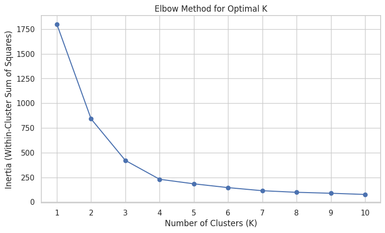

```python
inertias = []
K_range = range(1, 11)
for k in K_range:
    km = KMeans(n_clusters=k, random_state=42, n_init=10)
    km.fit(scaled)
    inertias.append(km.inertia_)

plt.figure()
plt.plot(list(K_range), inertias, marker="o")
plt.xlabel("Number of Clusters (K)")
plt.ylabel("Inertia (Within-Cluster Sum of Squares)")
plt.title("Elbow Method for Optimal K")
plt.xticks(list(K_range))
plt.show()
```

**Observation:** The elbow (the point where inertia stops dropping sharply) appears around **K=4**, matching the intuition that customers naturally fall into a handful of behavioural groups.

## 6. Apply K-Means with K=4

```python
K_OPTIMAL = 4
kmeans = KMeans(n_clusters=K_OPTIMAL, random_state=42, n_init=10)
df["Cluster"] = kmeans.fit_predict(scaled)
df["Cluster"].value_counts().sort_index()
```

```
Cluster
0    129
1    129
2    153
3    189
Name: count, dtype: int64
```

## 7. Visualise Clusters

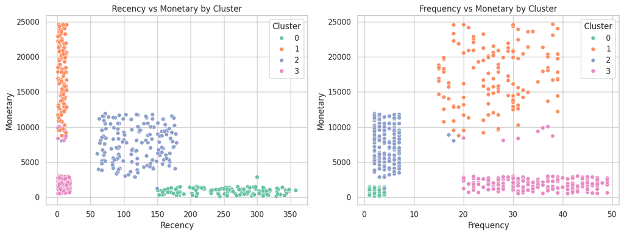

```python
fig, axes = plt.subplots(1, 2, figsize=(13,5))

sns.scatterplot(data=df, x="Recency", y="Monetary", hue="Cluster", palette="Set2", ax=axes[0])
axes[0].set_title("Recency vs Monetary by Cluster")

sns.scatterplot(data=df, x="Frequency", y="Monetary", hue="Cluster", palette="Set2", ax=axes[1])
axes[1].set_title("Frequency vs Monetary by Cluster")

plt.tight_layout()
plt.show()
```

## 8. Cluster Profiling

```python
cluster_profile = df.groupby("Cluster")[["Recency","Frequency","Monetary"]].mean().round(1)
cluster_profile["CustomerCount"] = df["Cluster"].value_counts().sort_index()
cluster_profile
```

| Cluster | Recency | Frequency | Monetary | CustomerCount |
| --- | --- | --- | --- | --- |
| 0 | 253.9 | 2.6 | 849.0 | 129 |
| 1 | 7.3 | 26.4 | 17406.3 | 129 |
| 2 | 117.4 | 4.7 | 7557.9 | 153 |
| 3 | 9.2 | 34.9 | 2111.6 | 189 |

**Interpreting the clusters** (labels will match your actual cluster numbers — check the profile table above):

- **Champions** — low Recency, high Frequency, high Monetary: your most valuable, most engaged customers.
- **Big spenders, lapsed** — high Recency but historically high Monetary: valuable customers who haven't purchased recently.
- **Frequent, low-value** — low Recency, high Frequency, low Monetary: loyal but small-basket shoppers.
- **At-risk / inactive** — high Recency, low Frequency, low Monetary: customers close to churning.

## 9. Customers per Cluster

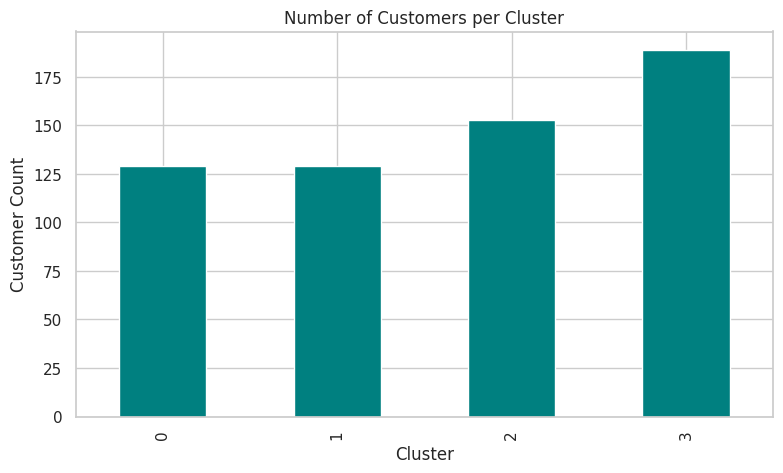

```python
plt.figure()
df["Cluster"].value_counts().sort_index().plot(kind="bar", color="teal")
plt.title("Number of Customers per Cluster")
plt.xlabel("Cluster")
plt.ylabel("Customer Count")
plt.show()
```

## 10. Marketing Recommendations by Segment

- **Champions:** Reward with loyalty perks and early access to new products — protect this high-value relationship.
- **Big spenders, lapsed:** Run a targeted win-back campaign (personalised discount or "we miss you" email) before they churn entirely.
- **Frequent, low-value:** Encourage bigger basket sizes with bundle deals or free-shipping thresholds.
- **At-risk / inactive:** Re-engagement campaign with a strong incentive (e.g. first-purchase-style discount) or, if unresponsive, deprioritise marketing spend on this group.